# ShotgunMG v1.3.0 user guide

## Summary

To summarize (Figure 1), the main pipeline worflow is defined in `shotgunmg.py` where each Job object will be instanciated and defined in either `bio/shotgun_metagenomics.py` or `bio/microbial_ecology.py`. Customizable parameters defined in the job definition of these two Python libraries are defined in the .ini file (`ShotgunMG.ini`).

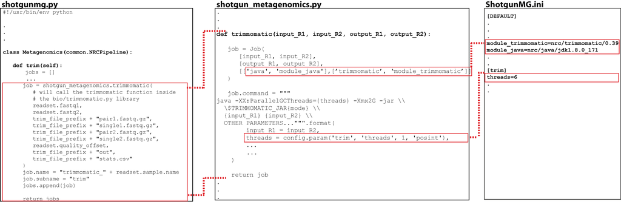

Figure 1. Summary of the interaction between main pipeline workflow, its libraries and the .ini file.

# 2- Workflow walkthrough

## Description of results generated by each job

For the sake of simplicity, only the commands themselves will be shown. For more details, the reader is referred to the complete `commands.sh` file example included in the supplementary material of the ShotgunMG website jtremblay.github.io/shotgunmg.html.

### Step 1 - trim

This step implements trimmomatic in the objective of removing sequencing adapters from each read and performing quality control to remove reads of low quality. A particular emphasis should be put in appropriately head and tail cropping the reads. Running FastQC on reads before and after trimming should be done to validate trimming step.

#### JOB: trimmomatic_<readset_name>

```
module load nrc/java/jdk1.8.0_144 nrc/trimmomatic/0.39 && \

java -XX:ParallelGCThreads=6 -Xmx2G -jar \$TRIMMOMATIC_JAR PE \
  -threads 6 \
  -phred33 \
  /raw_reads/Microbial_Mock_Community_Staggered_B_R1.fastq.gz ./raw_reads/Microbial_Mock_Community_Staggered_B_R2
.fastq.gz \
  qced_reads/Microbial_Mock_Community_Staggered_B/Microbial_Mock_Community_Staggered_B.trim.pair1.fastq.gz qced_reads/Microbial_Mock_Community_Staggered_B/Microbial_Mock_Community_Staggered_B.trim.single1.fastq.gz qced_reads/Microbial_Mock_Community_Staggered_B/Microbial_Mock_Community_Staggered_B.trim.pair2.fastq.gz qced_reads/Microbial_Mock_Community_Staggered_B/Microbial_Mock_Community_Staggered_B.trim.single2.fastq.gz \
  ILLUMINACLIP:$INSTALL_HOME/databases/contaminants/adapters-nextera-xt.fa:2:10:10 \
  TRAILING:30 \
  SLIDINGWINDOW:4:15 \
  MINLEN:45 \
  HEADCROP:16 CROP:96 \
  2> qced_reads/Microbial_Mock_Community_Staggered_B/Microbial_Mock_Community_Staggered_B.trim.out && \
grep ^Input qced_reads/Microbial_Mock_Community_Staggered_B/Microbial_Mock_Community_Staggered_B.trim.out | perl -pe 's/^Input Read Pairs: (\d+).*Both Surviving: (\d+).*Forward Only Surviving: (\d+).*$/Raw Fragments,\1\nFragment Surviving,\2\nSingle Surviving,\3/' > qced_reads/Microbial_Mock_Community_Staggered_B/Microbial_Mock_Community_Staggered_B.trim.stats.csv
NRC_STATE=\$PIPESTATUS
```

Purpose: To perform quality control to remove reads of low quality and trimming sequencing adapters.

.ini:

```
[trim]
threads=6
trailing_min_quality=30
average_quality=30
min_length=45
# Have a look at the fastqc profiles to make sure you are cropping enough bases at the beginning of the reads.
headcrop=16
# crop is optional. If for some reason you are still stuck with overrepresented kmers at the end, use crop=<in> to force them off.
crop=96
adapter_fasta=$INSTALL_HOME/databases/contaminants/adapters-nextera-xt.fa
illumina_clip_settings=:2:10:10
cluster_walltime=-t 6:00:0
cluster_cpu=-N 1 -n 6
cluster_pmem=--mem=32000
```

### Step 2- remove_contam

#### JOB: bbduk_paired_

```
module load nrc/bbmap/38.11 && \

bbduk.sh \
  in=qced_reads/Microbial_Mock_Community_Staggered_B/Microbial_Mock_Community_Staggered_B.trim.pair1.fastq.gz \
  in2=qced_reads/Microbial_Mock_Community_Staggered_B/Microbial_Mock_Community_Staggered_B.trim.pair2.fastq.gz \
  out=qced_reads/Microbial_Mock_Community_Staggered_B/Microbial_Mock_Community_Staggered_B.ncontam_paired_R1.fastq.gz \
  out2=qced_reads/Microbial_Mock_Community_Staggered_B/Microbial_Mock_Community_Staggered_B.ncontam_paired_R2.fastq.gz \
  outm=qced_reads/Microbial_Mock_Community_Staggered_B/Microbial_Mock_Community_Staggered_B.contam_R1.fastq \
  outm2=qced_reads/Microbial_Mock_Community_Staggered_B/Microbial_Mock_Community_Staggered_B.contam_R2.fastq \
  stats=qced_reads/Microbial_Mock_Community_Staggered_B/Microbial_Mock_Community_Staggered_B.duk_contam_interleaved_log.txt \
  k=21 \
  minkmerhits=1 \
  ref=$INSTALL_HOME/databases/contaminants/Illumina.artifacts.fa \
  overwrite=true \
  threads=1
```

Purpose:

To scan fastq libraries for known sequencing contaminants and remove them.

.ini:

```
[DEFAULT]
contaminants=$INSTALL_HOME/databases/contaminants/Illumina.artifacts.fa

[bbduk]
k=21
c=1
cluster_walltime=-t 12:00:0
cluster_cpu=-N 1 -n 1
cluster_pmem=--mem=12000
```

### Step 3- assembly

For the sake of simplicity, the above two steps only showed command examples for one readset. Here for the co-assembly job we show the command with the full readset (6 readsets). Assembly can be done using either spades or megahit. Megahit is much faster than spades and often proved to be the only realist package to use to assemble large sequencing datasets.

#### JOB: assembly

```
module load nrc/megahit/1.2.9 && \

rm assembly -rf && \
megahit -t 32 --k-min 31 --k-max 131 --k-step 10 \
  --min-contig-len 1000 \
  -1 qced_reads/Microbial_Mock_Community_Staggered_B/Microbial_Mock_Community_Staggered_B.ncontam_paired_R1.fastq.gz,qced_reads/Microbial_Mock_Community_Even_C/Microbial_Mock_Community_Even_C.ncontam_paired_R1.fastq.gz,qced_reads/Microbia
l_Mock_Community_Staggered_A/Microbial_Mock_Community_Staggered_A.ncontam_paired_R1.fastq.gz,qced_reads/Microbial_Mock_Community_Staggered_C/Microbial_Mock_Community_Staggered_C.ncontam_paired_R1.fastq.gz,qced_reads/Microbial_Mock_Community_Even_A/Microbial_Mock_Community_Even_A.ncontam_paired_R1.fastq.gz,qced_reads/Microbial_Mock_Community_Even_B/Microbial_Mock_Community_Even_B.ncontam_paired_R1.fastq.gz \
  -2 qced_reads/Microbial_Mock_Community_Staggered_B/Microbial_Mock_Community_Staggered_B.ncontam_paired_R2.fastq.gz,qced_reads/Microbial_Mock_Community_Even_C/Microbial_Mock_Community_Even_C.ncontam_paired_R2.fastq.gz,qced_reads/Microbial_Mock_Community_Staggered_A/Microbial_Mock_Community_Staggered_A.ncontam_paired_R2.fastq.gz,qced_reads/Microbial_Mock_Community_Staggered_C/Microbial_Mock_Community_Staggered_C.ncontam_paired_R2.fastq.gz,qced_reads/Microbial_Mock_Community_Even_A/Microbial_Mock_Community_Even_A.ncontam_paired_R2.fastq.gz,qced_reads/Microbial_Mock_Community_Even_B/Microbial_Mock_Community_Even_B.ncontam_paired_R2.fastq.gz \
  --out-dir assembly && \
sed -i 's/^>\\(\\S\\+\\) .*/>\\1/' assembly/final.contigs.fa && \
ln -s -f final.contigs.fa Contigs.fasta && mv Contigs.fasta ./assembly/
```

Purpose:

To generate assembled contigs from short reads data.

.ini:

```
[megahit]
# Megahit will use 0.9 pc of the node's memory by default.
min_contig_length=1000
num_threads=32
kmin=31
kmax=131
kstep=10
cluster_walltime=-t 12:00:0
cluster_cpu=-N 1 -n 32
cluster_pmem=--mem=514500
```

### Step 4- gene_prediction

Use Prodigal to predict ORFs on contigs

### Step 5- abundance

Map qced reads on contigs + generate contigs and gene abundance matrices.

### Step 6- exonerate

Split co-assembly and predicted genes fasta files in smaller chunks to perform downstream annotations.

### Step 7- diamond_blastp_kegg

DIAMOND BLASTp of predicted genes vs KEGG db.

### Step 8- rpsblast_cog

RPSBLAST of predicted genes vs COG db

### Step 9- rpsblast_kog

RPSBLAST of predicted genes vs KOG db

### Step 10- hmmscan_pfam

HMMSCAN of predicted genes vs PFAM-A DB.

### Step 11- diamond_blastp_nr

DIAMOND BLASTp of predicted genes vs NCBI nr

### Step 12- ncrna

scan for non-coding RNA in contigs: rRNA and tRNA sequence.

### Step 13- taxonomic_annotation

Using DIAMOND blastp results generated in the diamond_blastp vs nr step, each contig will be assigned a taxonomic lineage using the CAT package. Taxonomic summaries and figures are then generated.

### Step 14- beta_diversity

Compute beta-diversity on contig abundance and gene abundance matrices

### Step 15- alpha_diversity

Compute alpha-diversity (RTK package) on contig abundance and gene abundance matrices

### Step 16- finalize

Merge all annotations data generated in steps 7-11 and step 13 in a single gff and tsv file

### Step 17- binning

Generates MAGs/bins with the metabat2 and/or maxbin2 software.

# 3- Smart restart mechanism

One very useful feature of ShotgunMG (and GenPipes-based pipelines) is its built-in smart-restart mechanism. For instance, let’s generate jobs for the first step of the pipeline by running the following command : `ShotgunMG.py -c ./ShotgunMG.ini -s 1 -o . -j slurm -r readset.tsv -z ./pipeline.json > ./commands.sh` and let’s have look at the job definition:

```
#-------------------------------------------------------------------------------
# JOB: trim_1_JOB_ID: trimmomatic_Microbial_Mock_Community_Staggered_B
#-------------------------------------------------------------------------------
JOB_NAME=trimmomatic_Microbial_Mock_Community_Staggered_B
JOB_DEPENDENCIES=
JOB_DONE=job_output/trim/trimmomatic_Microbial_Mock_Community_Staggered_B.f72f4f889cb8f8cf9fcbfac1758b80b5.nrc.done
JOB_OUTPUT_RELATIVE_PATH=$STEP/${JOB_NAME}_$TIMESTAMP.o
JOB_OUTPUT=$JOB_OUTPUT_DIR/$JOB_OUTPUT_RELATIVE_PATH
trim_1_JOB_ID=$(echo "#!/bin/sh
rm -f $JOB_DONE && \
set -o pipefail
module load nrc/java/jdk1.8.0_144 nrc/trimmomatic/0.39 && \

java -XX:ParallelGCThreads=6 -Xmx2G -jar \$TRIMMOMATIC_JAR PE \
  -threads 6 \
  -phred33 \
  ./raw_reads/Microbial_Mock_Community_Staggered_B_R1.fastq.gz ./raw_reads/Microbial_Mock_Community_Staggered_B_R2.fastq.gz \
  qced_reads/Microbial_Mock_Community_Staggered_B/Microbial_Mock_Community_Staggered_B.trim.pair1.fastq.gz qced_reads/Microbial_Mock_Community_Staggered_B/Microbial_Mock_Community_Staggered_B.trim.single1.fastq.gz qced_reads/Microbial_Mock_Community_Staggered_B/Microbial_Mock_Community_Staggered_B.trim.pair2.fastq.gz qced_reads/Microbial_Mock_Community_Staggered_B/Microbial_Mock_Community_Staggered_B.trim.single2.fastq.gz \
  ILLUMINACLIP:$INSTALL_HOME/databases/contaminants/adapters-nextera-xt.fa:2:10:10 \
  TRAILING:30 \
  SLIDINGWINDOW:4:15 \
  MINLEN:45 \
  HEADCROP:16 CROP:96 \
  2> qced_reads/Microbial_Mock_Community_Staggered_B/Microbial_Mock_Community_Staggered_B.trim.out && \
grep ^Input qced_reads/Microbial_Mock_Community_Staggered_B/Microbial_Mock_Community_Staggered_B.trim.out | perl -pe 's/^Input Read Pairs: (\d+).*Both Surviving: (\d+).*Forward Only Surviving: (\d+).*$/Raw Fragments,\1\nFragment Surviving,\2\nSingle Surviving,\3/' > qced_reads/Microbial_Mock_Community_Staggered_B/Microbial_Mock_Community_Staggered_B.trim.stats.csv
NRC_STATE=\$PIPESTATUS
echo NRC_exitStatus:\$NRC_STATE
if [ \$NRC_STATE -eq 0 ] ; then touch $JOB_DONE ; fi
exit \$NRC_STATE" | \
sbatch --account=my-account --export=ALL -D $OUTPUT_DIR -o $JOB_OUTPUT -J $JOB_NAME -t 6:00:0  --mem=32000 -N 1 -n 6  | grep -o "[0-9]*")
echo "$trim_1_JOB_ID    $JOB_NAME   $JOB_DEPENDENCIES   $JOB_OUTPUT_RELATIVE_PATH" >> $JOB_LIST
```

The value stored in the JOB_DONE variable `JOB_DONE=job_output/trim/trimmomatic_Microbial_Mock_Community_Staggered_B.f72f4f889cb8f8cf9fcbfac1758b80b5.nrc.done`  
is actually an md5 signature of all the files creation date, names and sizes combined with all the job’s parameters used to generate the job. Once properly executed on the compute cluster and an `exit_status=0` is returned, the file defined by the JOB_DONE variable will be touched (i.e. created) (`if [ \$NRC_STATE -eq 0 ] ; then touch $JOB_DONE ; fi`).  
Once this job has successfully completed, if we decide to run the first step of the pipeline again (`ShotgunMG.py -c ./ShotgunMG.ini -s 1 -o . -j slurm -r readset.tsv -z ./pipeline.json > ./commands.sh`), we’ll find that no job was written in the standard output `commands.sh` file. This is because during the job generation process, the pipeline detected that this job was up to date, because:  
1) infiles (fastq.gz files) of the job were older than the outfiles (`.pair1.fastq.gz, .pair2.fastq.gz, .single1.fastq.gz, single2.fastq.gz`) it generated,  
2) no changes whatsoever were done on the input files and in consequence,  
3) the file size of the input files remained the same.  
4) There were no modifications in the parameters in the .ini file under the [trim] section. Overall, the md5 signature is identical between the executed job and the new Job object and in consequence, no new job is created. If we would have modified the header of one of the fastq headers in one of the fastq file and had rerun the pipeline, this job would have been re-generated, because the pipeline would have found differences in the old and new md5 signed `.done` file. This mechanism is useful if for some reason we realized that one of the parameter given to trimmomatic was not optimal. For instance, if we would increase the crop value from 96 to 100, upon re-execution of `shotgunmg.py`, all the trimmomatic jobs would be regenerated because the md5 signature of the old `.done` file would not match the new md5 signature of the new job anymore - in other words, the job would not be up-to-date anymore and would in consequence be re-generated. This mechanism is also useful in the context of random job failure because of a faulty compute node or (as described above) if the pipeline operator is interested in modifying one or many variables of a given step of the pipeline.  
Another instance where this mechanism is useful is when a job crashes because we didn’t asked for enough memory or cores for its execution and SLURM detects this and kills off our job because the limits of the resources we asked for were not respected. When that happens, an exit_status other than 0 is returned for that offending job and the rest of the downstream dependent jobs are then killed by SLURM. Instead of manually going through each single job that went through to find which one returned a non-zero exit_status, the pipeline operator can simply rerun `ShotgunMG.py` with the same parameters and see which jobs are generated.

# 4- End results

The arguably most important results generated by the pipeline are the following files:

## Read counts

Contains read count summary throughout the different steps of the pipeline.

```
contig_abundance/qc_mappping_stats.tsv
```

## Co-assembly

Co-assembly fasta file:

```
assembly/Contigs.fasta
```

Statistics and profiles of co-assembly.

```
assembly/assembly_stats.txt
assembly/quast/report.html
```

## Gene prediction

Predicted genes in fna, faa and gff formats:

```
gene_prediction/Contigs_renamed.fna
gene_prediction/Contigs_renamed.faa
gene_prediction/Contigs_renamed.gff
```

## Contigs and genes abundance matrices

Text files in .tsv format. Un normalized (absolute number of qced reads that properly aligned to genes or contigs):

```
gene_abundance/merged_gene_abundance.tsv
contig_abundance/merged_contig_abundance.tsv
```

Normalized abundance - using edgeR package with TMM method - gives Count Per Million (CPM):

```
gene_abundance/merged_gene_abundance_cpm.tsv
contig_abundance/merged_contig_abundance_cpm.tsv
```

## Annotations

All merged annotations (except ncrna) combined in a .tsv file

```
annotations/annotations.tsv
```

## Alpha diversity

Contains the alpha diversity values. Observed contigs/genes (richness), shannon, etc.

```
alpha_div/contig_abundance/alpha_richness.tsv
alpha_div/contig_abundance/alpha_shannon.tsv
alpha_div/gene_abundance/alpha_richness.tsv
alpha_div/gene_abundance/alpha_shannon.tsv
```

## Beta diversity

Contains the beta diversity (Bray-Curtis dissimilarity) distance matrices, PCoAs and interactive figures computed from contig and gene abundance matrices. Interactive 3d figures that can be opened in most internet browsers. Beta diversity metrics are generated using microbiomeutils (https://github.com/jtremblay/microbiomeutils)

```
betadiv/bray_curtis_contig_bacteriaArchaea/3d_bray_curtis_plot/index.html
betadiv/bray_curtis_contig_abundance/3d_bray_curtis_plot/index.html
betadiv/bray_curtis_gene_abundance/3d_bray_curtis_plot/index.html
```

Distance matrices.

```
betadiv/bray_curtis_contig_abundance/bray_curtis_contig_abundance.tsv
betadiv/bray_curtis_contig_bacteriaArchaea/bray_curtis_contig_bacteriaArchaea.tsv
betadiv/bray_curtis_gene_abundance/bray_curtis_gene_abundance.tsv
```

Principal coordinates analysis tables computed from the distance matrices described above.

```
betadiv/bray_curtis_contig_abundance/bray_curtis_contig_abundance_coords.tsv
betadiv/bray_curtis_contig_bacteriaArchaea/bray_curtis_contig_bacteriaArchaea_coords.tsv
betadiv/bray_curtis_gene_abundance/bray_curtis_gene_abundance_coords.tsv
```

## DIAMOND BLASTp output of genes vs KEGG genes DB

```
annotations/blastp_kegg.tsv
annotations/blastp_kegg_parsed.tsv
```

## DIAMOND BLASTp output of genes vs NCBI nr DB

```
annotations/blastp_nr.tsv
```

## hmmscan output of genes vs PFAM-A DB.

Three different types of output are provided. Please consult HMMer 3 documentation for more details.

```
annotations/hmmscan_pfam_domtblout.tsv
annotations/hmmscan_pfam_pfamtblout.tsv
annotations/hmmscan_pfam_tblout.tsv
```

## tRNA (tRNAscan) and rRNA (barrnap) abundance/annotations

```
# tRNA
annotations/trna/trna*tsv

# rRNA
annotations/rrna/rdp/*
annotations/rrna/barrnap/*
annotations/rrna/abundance/*
annotations/rrna/abundance/arc_SSU_merged_abundance.tsv
annotations/rrna/abundance/bac_LSU_merged_abundance.tsv
annotations/rrna/abundance/bac_SSU_merged_abundance.tsv
annotations/rrna/abundance/euk_LSU_merged_abundance.tsv
annotations/rrna/abundance/euk_SSU_merged_abundance.tsv
```

## Taxonomic profiles

Taxonomic profile tables at L1=kindgom, L2=phylum, L3=class, L4=order, L5=family and L6=genus. Both in absolute (consensus rarefaction) or relative. abundance.

```
# All organisms
annotations/taxonomy_consensus/all/absolute/
annotations/taxonomy_consensus/all/relative/
# Bacteria/Archaea only
annotations/taxonomy_consensus/bacteriaArchaea/absolute/
annotations/taxonomy_consensus/bacteriaArchaea/relative/
# Non-bacterial/archaeal:
annotations/taxonomy_consensus/others/absolute/
annotations/taxonomy_consensus/others/relative/
```

# 5- Job output folder

When a job is launched/submitted whether on the job scheduler or directly on the terminal with the `batch` option, the standard output and error are redirected and written in the `./job_output/` folder in the step subfolder that this job belongs to. For instance, consider the following job, where we have a `JOB_OUTPUT_DIR` set to `./job_output`. The trim step (step 1) will generate a subdirectory :

```
STEP=trim
mkdir -p $JOB_OUTPUT_DIR/$STEP
```

For instance, if we look at the `trimmomatic_Microbial_Mock_Community_Even_A` job, we have the following instructions which will define the file that will hold the standard output and error:

```
JOB_NAME=trimmomatic_Microbial_Mock_Community_Even_A
JOB_DEPENDENCIES=
JOB_OUTPUT_RELATIVE_PATH=$STEP/${JOB_NAME}_$TIMESTAMP.o
```

Finally, when the job is submitted to the job scheduler with the following command: `sbatch --account=my_account_xyz --export=ALL --mail-type=END --mail-user=$JOB_MAIL -D $OUTPUT_DIR -o $JOB_OUTPUT -J $JOB_NAME -t 6:00:0 --mem=32000 -N 1 -n 6`, the `-o $JOB_OUTPUT` instructs the job scheduler were to write the standard output and error.

Here is the complete chunk of instructions:

[output not shown]

# 6- Integrating more options in a given bioinformatics package

One useful feature of ShotgunMG (and the GenPipes WMS) is the possibility to customize each step of a workflow. For instance, if we would want to add an option for Megahit, we would need to add a few lines of code to the `megahit` function found in the `bio/shotgun_metagenomics.py` file. As a reminder, the `megahit_R1_R2` function is called from the main pipeline script/wrapper `shotgunmg.py`:

```python
job = shotgun_metagenomics.megahit_R1_R2(
  fastq_gz_list_R1,
  fastq_gz_list_R2,
  os.path.join("assembly"),
  reads_type
)
job.name = "megahit"
job.subname = "megahit"
jobs.append(job)
```

where a job object will be instantiated in the `megahit_R1_R2` function of the `bio/shotgun_metagenomics.py` library:

```python
def megahit_R1_R2(infiles_R1, infiles_R2, outdir, type):

  if(type == "pe"):
    infiles_string_R1 = "-1 " + ",".join(infiles_R1);
    infiles_string_R2 = "-2 " + ",".join(infiles_R2);

  job = Job(
    infiles_R1 + infiles_R2,
    [os.path.join(outdir, "Contigs.fasta"), os.path.join(outdir, "final.contigs.fa")],
    [
      ['megahit', 'module_megahit']
    ]
  )
  job.command="""
rm {outdir} -rf && \\
megahit -t {num_threads} --k-min {kmin} --k-max {kmax} --k-step {kstep} \\
  --min-contig-len {min_contig_length} \\
  {infiles_R1} \\
  {infiles_R2} \\
  --out-dir {outdir} && \\
sed -i 's/^>\\\(\\\S\\\+\\\) .*/>\\\\1/' final.contigs.fa && \\
ln -s -f final.contigs.fa Contigs.fasta && mv Contigs.fasta ./assembly/""".format(
    min_contig_length = config.param("megahit", "min_contig_length", 1, "posint"),
    num_threads = config.param("megahit", "num_threads", 1, "posint"),
    kmin = config.param("megahit", "kmin", 1, "posint"),
    kmax = config.param("megahit", "kmax", 1, "posint"),
    kstep = config.param("megahit", "kstep", 1, "int"),
    infiles_R1 = infiles_string_R1,
    infiles_R2 = infiles_string_R2,
    outdir = outdir
  )

  return job
```

```python
def megahit_R1_R2(infiles_R1, infiles_R2, outdir, type):

  if(type == "pe"):
    infiles_string_R1 = "-1 " + ",".join(infiles_R1);
    infiles_string_R2 = "-2 " + ",".join(infiles_R2);

  job = Job(
    infiles_R1 + infiles_R2,
    [os.path.join(outdir, "Contigs.fasta"), os.path.join(outdir, "final.contigs.fa")],
    [
      ['megahit', 'module_megahit']
    ]
  )
  job.command="""
rm {outdir} -rf && \\
megahit -t {num_threads} --k-min {kmin} --k-max {kmax} --k-step {kstep} \\
  --min-contig-len {min_contig_length} \\
  {infiles_R1} \\
  {infiles_R2} \\
  --out-dir {outdir} && \\
sed -i 's/^>\\\(\\\S\\\+\\\) .*/>\\\\1/' assembly/final.contigs.fa && \\
ln -s -f final.contigs.fa Contigs.fasta && mv Contigs.fasta ./assembly/""".format(
    min_contig_length = config.param("megahit", "min_contig_length", 1, "posint"),
    num_threads = config.param("megahit", "num_threads", 1, "posint"),
    kmin = config.param("megahit", "kmin", 1, "posint"),
    kmax = config.param("megahit", "kmax", 1, "posint"),
    kstep = config.param("megahit", "kstep", 1, "int"),
    prune_level = config.param("megahit", "prune_level", 1, "int"), #!! <--- Here we added a new option
    infiles_R1 = infiles_string_R1,
    infiles_R2 = infiles_string_R2,
    outdir = outdir
  )

  return job
```

We would also need to add the option `prune_level` in the `.ini` file under the `[megahit]` category.

```
[megahit]
# Megahit will use 0.9 pc of the node's memory by default.
min_contig_length=1000
num_threads=32
kmin=31
kmax=131
kstep=10
prune_level=3
cluster_walltime=-t 12:00:0
cluster_cpu=-N 1 -n 32
cluster_pmem=--mem=514500
```

We should be ready to go with this new option implementation. Adding an option for Megahit is a simple case scenario as it consists in the simple implementation of an additional argument to the megahit command.